# Spatial Data Visualisation

# 1. Creating spatial data visualisation using the **raster** Package

One package used to create spatial data visualisations is the **raster** package, with the **getData()** function used to obtain spatial data, before plotting it with **ggplot2** or other packages such as leaflet. In this example, we will be looking to plot a map of france, highlighting deaths due to COVID-19 across the regions.

```r
library(tidyverse)
library(raster) # For the "getData" function, Full list of countries are available at https://gadm.org/maps.html
library(ggplot2)
library(tigris) # For the "geo_join" function
library(scales) # For the "breaks_pretty" function
library(rgdal) # For the "spTransform" function
library(broom) # For the "tidy" function.
```

```r
france <- getData('GADM', country = 'FRA', level = 1)

france <- spTransform(france, CRS("+init=EPSG:32631")) # To make map projections more accurate
```

Using the **getData()** function, countries are identified by their ISO code, with a list [here](https://www.nationsonline.org/oneworld/country_code_list.htm).  
level = 0 gives you country outline, and level = 1 gives you regional boundaries.  
If you are looking for the most accurate visualisation, you should use spTransform to reproject the area you are going to plot to make the resulting visualisation more accurate. To perform this step:  
1) Obtain the longitude and latitude of the location you are looking to plot (either online or with a package).  
2) Enter the longitude and latitude [here](http://www.dmap.co.uk/ll2tm.htm), and convert the coordinates to a grid reference using the “UTM (WGS84)” Grid Area. With the coordinates 46.2276° N, 2.2137° E, the resulting grid number would be 31. Your grid square would be N, based on your latitude, giving you a resulting UTM grid of 31N.  
3) In this [Spatial Reference Website](https://spatialreference.org/ref/epsg/), enter your UTM grid in the search references, and you will see a list of EPSG references. Copy the one used for WGS84 grid, and that goes into the CRS argument of the spTransform function, as seen above.

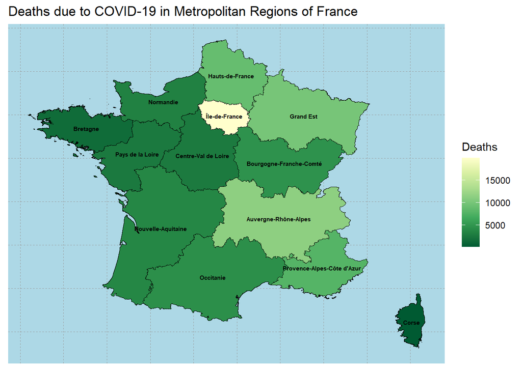

```r
# Data cleaning to obtain our desired covid dataset

# Function to keep regions that are only available in the getData function
seek <- function(x, y) {
  return(any(grepl(x,y,ignore.case = TRUE)))
}

# To obtain data from Metropolitan French regions as defined in the getData function, with matching names
covid <- read.csv("jrc-covid-19-all-days-by-regions.csv") # Covid -19 dataset
covidfr <- covid[covid$CountryName == "France",] # Including only data from france
covidfr$Region <- gsub("Auvergne-RhÃ´ne-Alpes", "Auvergne-Rhône-Alpes", covidfr$Region)
covidfr$Region <- gsub("ÃŽle-de-France", "Île-de-France", covidfr$Region)
covidfr$Region <- gsub("Bourgogne-Franche-ComtÃ©", "Bourgogne-Franche-Comté", covidfr$Region)
covidfr$Region <- gsub("Provence-Alpes-CÃ´te d'Azur", "Provence-Alpes-Côte d'Azur", covidfr$Region)
covidfr <- covidfr[covidfr$Region != "",] # Removing blank regions
covidfr <- covidfr[sapply(covidfr$Region, seek, france@data$NAME_1),]
# To obtain cumulative number of deaths per region in France
covidfr <- covidfr %>% group_by(Region) %>% summarise(deaths = max(CumulativeDeceased))

## To combine covid data with spatial data previously obtained, and converting the result to a dataframe
france@data$id <- rownames(france@data)
france_merged <- geo_join(france, covidfr, "NAME_1", "Region") # The merge function can be used as well
# tidy is used to convert spatial dataframe to a dataframe to be used for geom_polygon
france_df <- tidy(france_merged)
france_df <- left_join(france_merged@data,france_df, by = "id")


centroid_df <- as.data.frame(coordinates(france))
centroid_df <- cbind(centroid_df, unique(france_df$NAME_1))
colnames(centroid_df) <- c("long","lat","Region")

# To standardise plot themes
theme_opts<-list(theme(panel.grid.minor = element_line(color = "gray60", linetype = "dashed", size = 0.25),
                       panel.grid.major = element_line(color = "gray60", linetype = "dashed", size = 0.25),
                       panel.background = element_rect(fill = "lightblue"),
                       plot.background = element_blank(),
                       axis.line = element_blank(),
                       axis.text.x = element_blank(),
                       axis.text.y = element_blank(),
                       axis.ticks = element_blank(),
                       axis.title.x = element_blank(),
                       axis.title.y = element_blank()))

# To highlight one specific region (The region with the highest number of deaths in this case)
covidfr_ordered <- order(covidfr$deaths, decreasing = TRUE)
highest_deaths_fr <- head(covidfr[covidfr_ordered,], 1)
highest_region <- france[france@data$NAME_1 == highest_deaths_fr$Region,]
highest_region <- tidy(highest_region)
# Plotting the various Spatial Data Visualisations

ggplot() +
  geom_polygon(data = france_df, aes(x = long,y = lat, group = group, fill = deaths), color = "black", size = 0.25) +
  geom_text(data = centroid_df, aes(label = Region, x = long, y = lat, fontface = "bold"), col = "black", size = 2) +
  theme_opts +
  scale_fill_distiller(name="Deaths", palette = "YlGn", breaks = breaks_pretty(n = 3)) +
  ggtitle("Deaths due to COVID-19 in Metropolitan Regions of France")
```

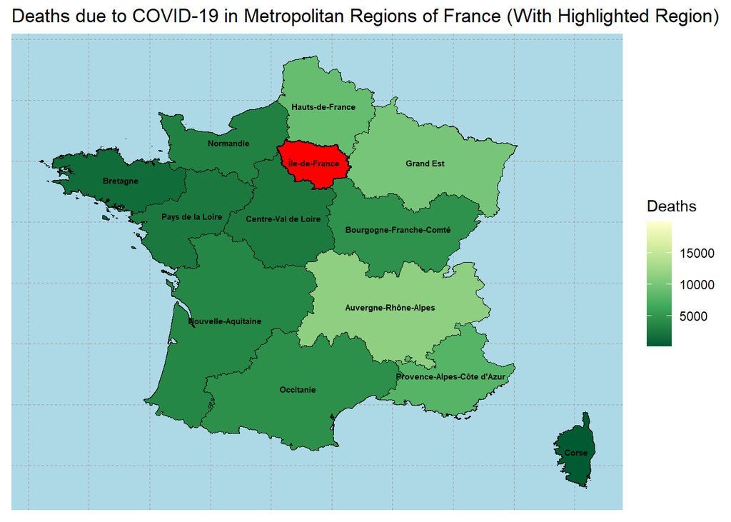

```r
# Region with greatest number of deaths is highlighted here
ggplot() +
  geom_polygon(data = france_df, aes(x = long,y = lat, group = group, fill = deaths), color = "black", size = 0.25) +
  # To highlight region with largest number of deaths
  geom_polygon(data = highest_region, aes(long,lat,group=group), fill = "red", color = "black") +
  geom_text(data = centroid_df, aes(label = Region, x = long, y = lat, fontface = "bold"), col = "black", size = 2) +
  theme_opts +
  scale_fill_distiller(name="Deaths", palette = "YlGn", breaks = breaks_pretty(n = 3)) +
  ggtitle("Deaths due to COVID-19 in Metropolitan Regions of France (With Highlighted Region)")
```

# 2. Using the **rnaturalearth** Package

Another package commonly used to create spatial data visualisations is the **rnaturalearth** package to obtain shape files. One advantage of the rnaturalearth package over the raster package is that it allows users to obtain spatial data for the world map and the different continents as well, instead of just countries.

```r
library(rnaturalearth)
library(rnaturalearthhires) # Required for scale = "large"
```

In the rnaturalearth package, pre-downloaded maps can be accessed with:  
1. **ne_countries()** for country (admin-0) boundaries  
2. **ne_states()** for boundaries within countries (admin-1)  
3. **ne_coastline()** for world coastline

```r
# Includes countries, dependencies, territories and islands as well
world <- ne_countries(scale = "large", returnclass = "sf")
```

To see all countries, dependencies, territories and islands covered by this package (Subjected to change as the package is updated):

```r
library(DT) # Used to obtain the datatable below
All_locations <- data.frame(Locations = world$admin)
datatable(All_locations, rownames = FALSE, options = list(pageLength = 10, lengthChange = F))
```

| Locations |
| --- |
| Indonesia |
| Malaysia |
| Chile |
| Bolivia |
| Peru |
| Argentina |
| Dhekelia Sovereign Base Area |
| Cyprus |
| India |
| China |

[output cut: 245 more lines]

We’re using **returnclass = “sf”** here to plot spatial data visualisations using **“sf”** class instead of **returnclass = “sp”**, which returns a “SpatialPolygonsDataFrame” or **“sp”** class, just like the **getData()** function used earlier. That way, we can plot our data with **geom_sf()** instead of **geom_polygon()**, which might be more convenient since it already takes into consideration the coordinate system, and allows us to easily choose the area we wish to show on our plot using the **coord_sf()** function. Also, we no longer have to use the **tidy()** function to convert our data into a dataframe.

Large scaled data is the most detailed, followed by medium and small for the “scale” argument.

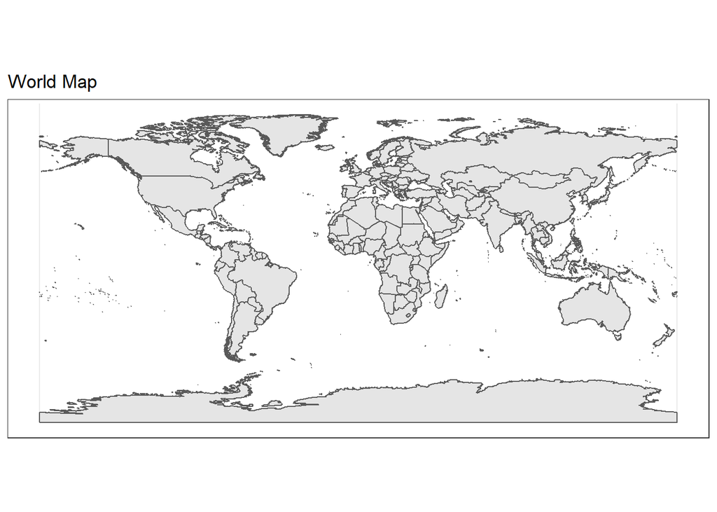

```r
# Plotting a map of the world displaying bombing cases in 2018
ggplot() +
  geom_sf(data = world) +
  ggtitle("World Map") +
  theme_bw()
```

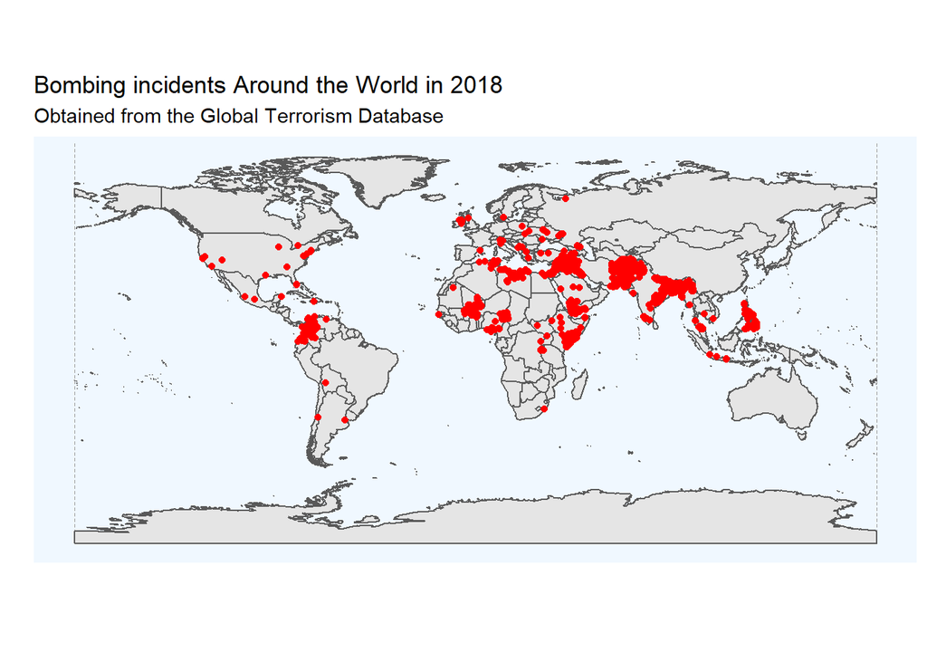

```r
terrorism <- read.csv("globalterrorismdb_0919dist.csv")
terrorism <- terrorism[terrorism$attacktype1_txt == "Bombing/Explosion" & terrorism$iyear == 2018,]

ggplot() +
  geom_sf(data = world) +
  geom_point(data = terrorism, aes(x = longitude, y = latitude), color = "red") +
  ggtitle(label = "Bombing incidents Around the World in 2018", subtitle = "Obtained from the Global Terrorism Database") +
  theme(panel.grid.major = element_line(color = "gray60", linetype = "dashed", size = 0.25),
        panel.background = element_rect(fill = "aliceblue")) +
  # This line of code below can be altered and included to manipulate the plotted area according to your desired       coordinates
  # coord_sf(xlim = c(100.00, 160.00), ylim = c(-45.00, -10.00), expand = FALSE) +
  xlab("") +
  ylab("")
```

Similar to the first map showing deaths due to COVID-19 in France, we can incorporate covid data from the same dataset into the spatial data obtained using **ne_countries()**, and plot a map showing deaths due to COVID-19 around the world/continent

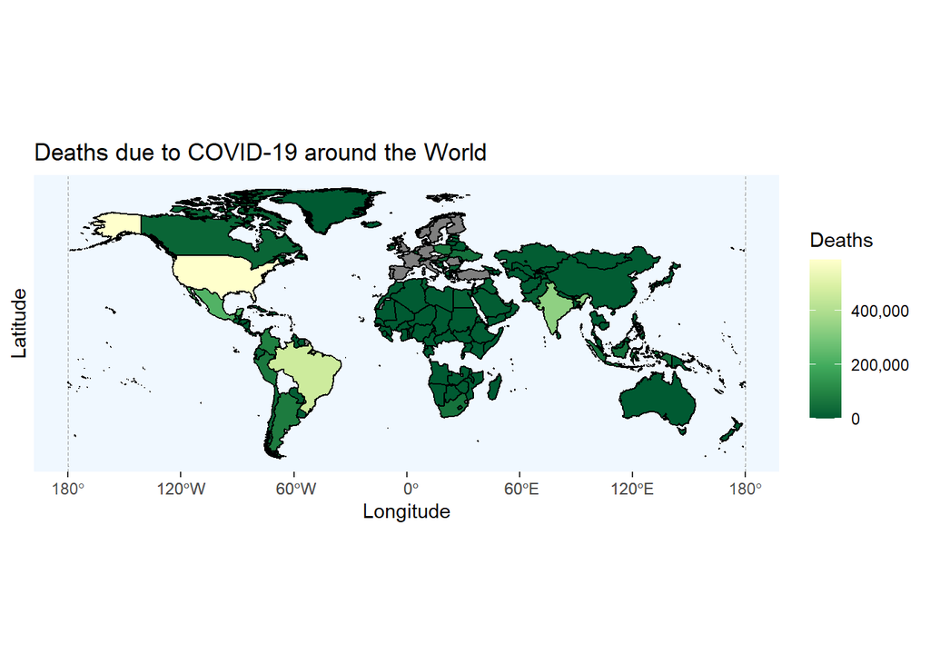

```r
# Plotting deaths due to COVID-19 around the world, using ne_countries()

covidworld <- read.csv("jrc-covid-19-all-days-by-regions.csv")
covidworld <- covid %>% group_by(CountryName) %>% summarise(deaths = max(CumulativeDeceased))
covidworld_df <- merge(world, covidworld, by.x = "admin", by.y = "CountryName")

ggplot() +
  geom_sf(data = covidworld_df, aes(fill = deaths), color = "black") +
  scale_fill_distiller(name="Deaths", palette = "YlGn", breaks = breaks_pretty(n = 3), labels = comma) +
  theme(panel.grid.major = element_line(color = "gray60", linetype = "dashed", size = 0.25),
        panel.background = element_rect(fill = "aliceblue")) +
  xlab("Longitude") +
  ylab("Latitude") +
  ggtitle("Deaths due to COVID-19 around the World")
```

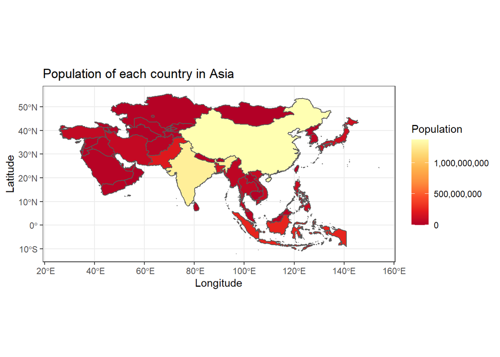

```r
# Plotting a map of Asia displaying the population sizes of each country
asia <- ne_countries(scale = "large", continent = "asia", returnclass = "sf")

ggplot() +
  geom_sf(data = asia, aes(fill = as.numeric(pop_est))) + # Population data is provided in the rnaturalearth package
  scale_fill_distiller(name="Population", palette = "YlOrRd", breaks = breaks_pretty(n = 3), labels = comma) +
  labs(x = "Longitude", y = "Latitude") +
  ggtitle("Population of each country in Asia") +
  # coord_sf(xlim = c(100.00, 160.00), ylim = c(-45.00, -10.00), expand = FALSE) +
  # coord_sf(xlim = c(-180.00, 0.00), expand = FALSE) +
  theme_bw() +
  theme(aspect.ratio = 0.5)
```

**rnaturalearth** can be used to plot individual country maps as well, but as you can see from the example below, it might be more visually appealling to plot country maps using the **getData()** function from the raster package instead.

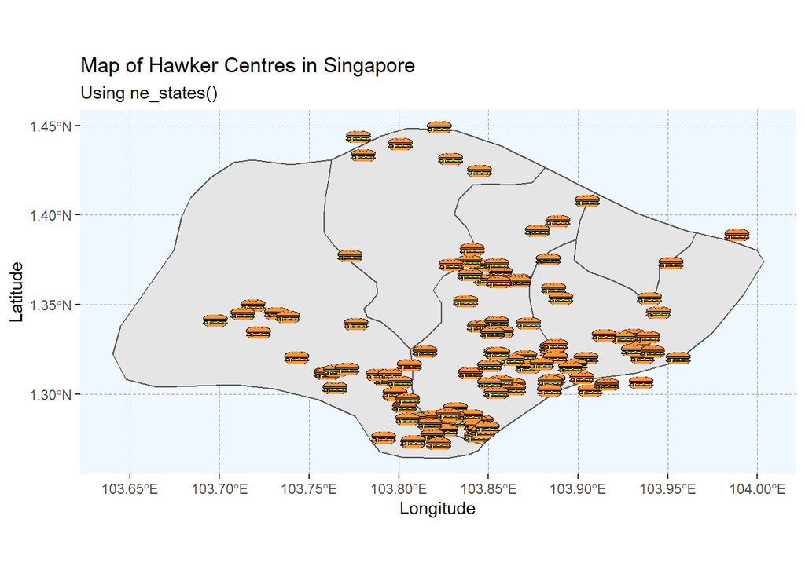

```r
library(ggimage)
# Plotting a map of Singapore displaying all hawker centres using ne_states()

singapore <- ne_states(country = "singapore", returnclass = "sf")
hawkers <- read.csv("hawker-centres-kml.csv")
image <- "https://image.flaticon.com/icons/png/512/3075/3075977.png"
hawkers <- cbind(hawkers,image)

ggplot() +
  geom_sf(data = singapore) +
  geom_image(data = hawkers, aes(x = X, y = Y, image = image), size = .035) +
  theme(panel.grid.major = element_line(color = "gray60", linetype = "dashed", size = 0.25),
        panel.background = element_rect(fill = "aliceblue")) +
  xlab("Longitude") +
  ylab("Latitude") +
  ggtitle("Map of Hawker Centres in Singapore", subtitle = "Using ne_states()")
```

```r
SG <- getData('GADM', country = 'SG', level = 1)
SG <- tidy(SG)
```

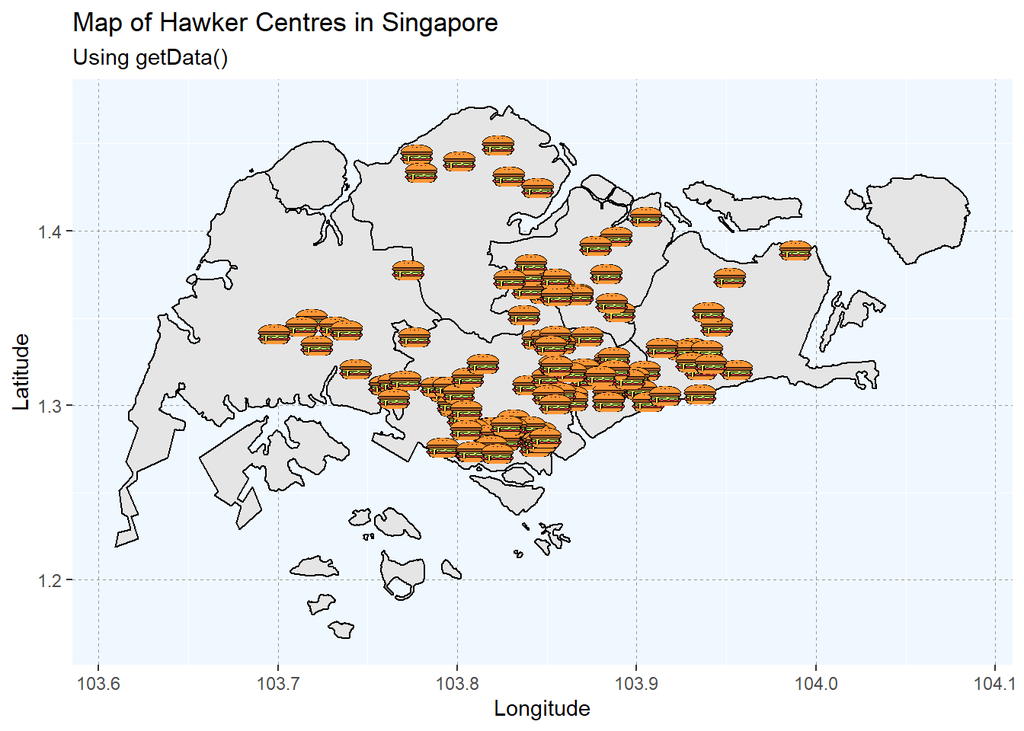

```r
ggplot() + geom_polygon(data = SG, aes(x = long, y = lat, group = group), fill = "grey90", color = "black") +
  xlab("Longitude") +
  ylab("Latitude") +
  #To show that images can be used to replace geom_point
  # geom_point(data = hawkers, aes(x = X, y = Y), color = "red") +
  geom_image(data = hawkers, aes(x = X, y = Y, image = image), size = .035) +
  theme(panel.grid.major = element_line(color = "gray60", linetype = "dashed", size = 0.25),
        panel.background = element_rect(fill = "aliceblue")) +
  ggtitle("Map of Hawker Centres in Singapore", subtitle = "Using getData()")
```

To show how we can plot the same map using both arguments of returnclass:

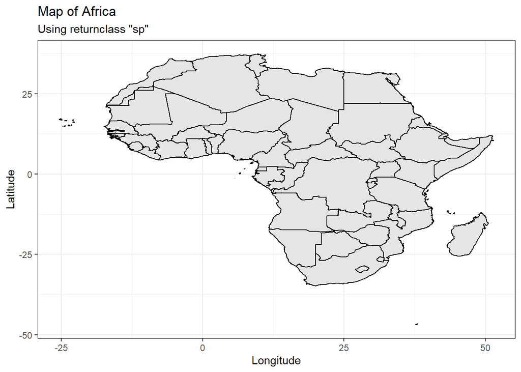

```r
# To plot using returnclass = "sp" and geom_polygon()

# Does not need to be specified if using returnclass = "sp"
africa_sp <- ne_countries(scale = "large", continent = "africa", returnclass = "sp")
africa_sp <- tidy(africa_sp)
ggplot() +
  geom_polygon(data = africa_sp, aes(x = long, y = lat, group = group), fill = "grey90", color = "black") +
  labs(x = "Longitude", y = "Latitude") +
  theme_bw() +
  ggtitle("Map of Africa", subtitle = "Using returnclass \"sp\"")
```

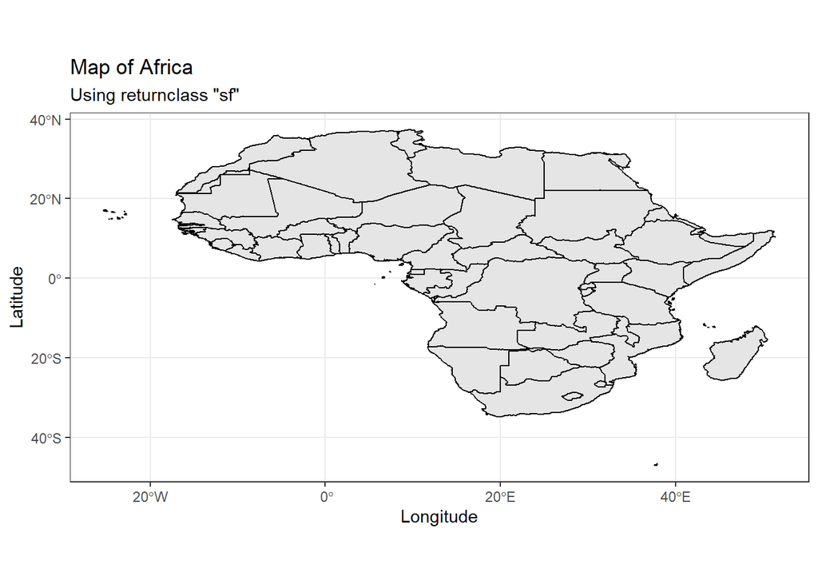

```r
# To plot the same map using returnclass = "sf"
africa_sf <- ne_countries(scale = "large", continent = "africa", returnclass = "sf")

ggplot() +
  geom_sf(data = africa_sf, fill = "grey90", color = "black") +
  xlab("Longitude") +
  ylab("Latitude") +
  theme_bw() +
  theme(aspect.ratio = 0.5) + # To make the plot look similar to the above, or it would look thinner
  ggtitle("Map of Africa", subtitle = "Using returnclass \"sf\"")
```

# 3. Using the **urbanmapr** Package

There is also a package **urbnmapr** that can be used specifically for obtaining spatial data about the United States. The benefit of this package is that Hawaii and Alaska are transformed to be displayed as insets within the continental United States, which might not be the case for other packages. The data provided in this package also requires minimal work to be merged with external datasets when creating your own visualisations.

However, before you can run the code below to install the package, you’ll have to install **rtools 4.0** and follow the instructions provided [here.](https://cran.r-project.org/bin/windows/Rtools/) Afterwards, you may install the package by running the code below, after installing the **devtools** package first.

```r
library(devtools)
install_github("UrbanInstitute/urbnmapr")
library(urbnmapr)
```

From there, we can either plot a map of the United States at states level (**urbnmapr::states**), or county level (**urbnmapr::counties**) using spatial data provided in the package. The **get_urbn_labels()** function also allows you to obtain centroid coordinates, which can be used to add labels to the map. In this document, it is necessary to specify the package that we use the “states” and “counties” functions from, as the tigris package already loaded to use the geo_join() function also contains functions that have the same names, and can be used to plot spatial data about the Unitd States as well.

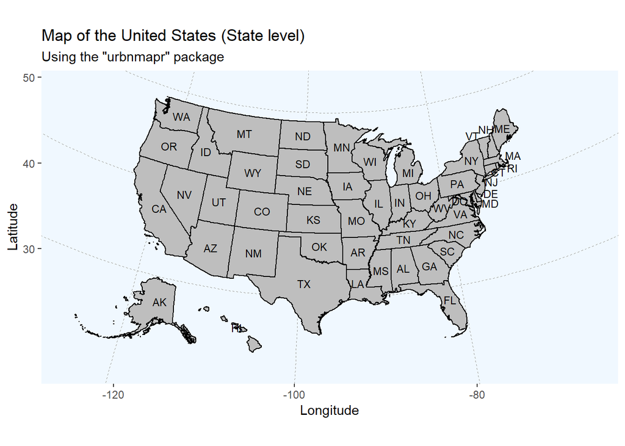

```r
# plotting at state level
states_label_data <- get_urbn_labels() # Default argument for map is "states", so it is unncessary to                                                         specify this

ggplot() +
  geom_polygon(data = urbnmapr::states, mapping = aes(x = long, y = lat, group = group),
                   fill = "grey", color = "black") +
  geom_text(data = states_label_data, aes(label = state_abbv, x = long, y = lat), size = 3) +
  coord_map(projection = "albers", lat0 = 39, lat1 = 45) + # Used to alter map projection for a nicer view
  xlab("Longitude") +
  ylab("Latitude") +
  ggtitle("Map of the United States (State level)", subtitle = "Using the \"urbnmapr\" package") +
  theme(panel.grid.major = element_line(color = "gray60", linetype = "dashed", size = 0.25),
        panel.background = element_rect(fill = "aliceblue"))
```

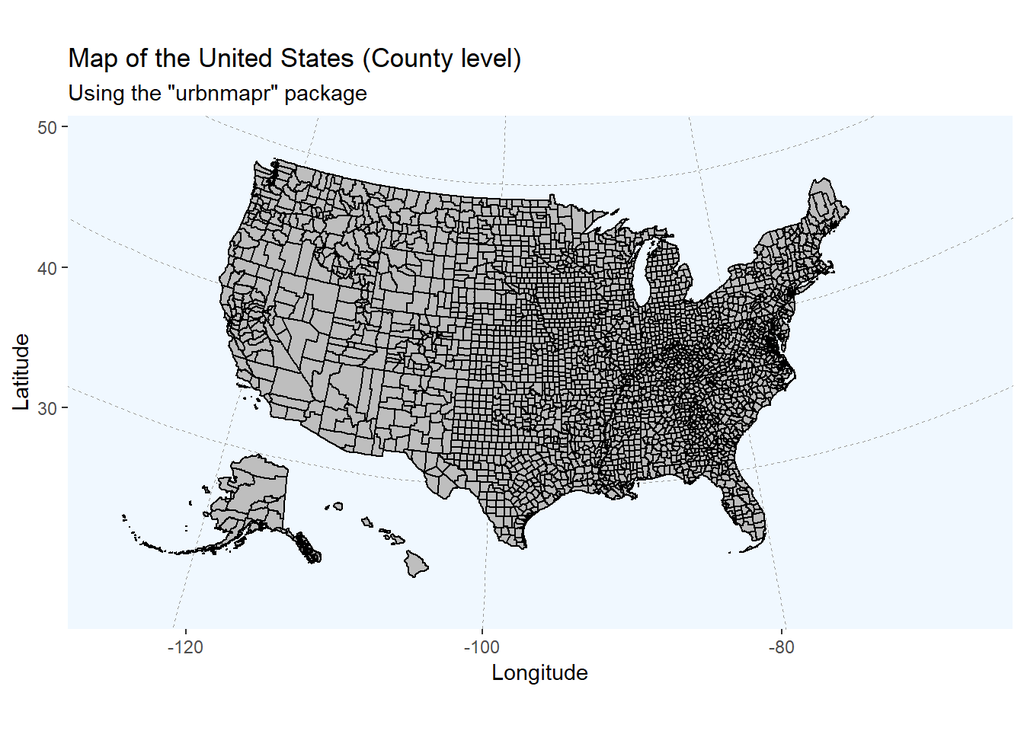

```r
# Plotting at county level
ggplot() +
  geom_polygon(data = urbnmapr::counties, mapping = aes(x = long, y = lat, group = group),
                   fill = "grey", color = "black") +
  coord_map(projection = "albers", lat0 = 39, lat1 = 45) + # Used to alter map projection for a nicer view
  xlab("Longitude") +
  ylab("Latitude") +
  ggtitle("Map of the United States (County level)", subtitle = "Using the \"urbnmapr\" package") +
  theme(panel.grid.major = element_line(color = "gray60", linetype = "dashed", size = 0.25),
        panel.background = element_rect(fill = "aliceblue"))
```

The state dataset (**urbnmapr::statedata**) includes state names, abbreviations, and Federal Information Processing Standards (FIPS) codes — unique numeric identifiers for each county and state. The county dataset (**urbnmapr::countydata**) includes all the state variables plus county names and FIPS codes, making it easy to merge with the data you are working with, whether they include names or codes. Both datasets include sample data from 2015 which you can use to incorporate into your map, such as Household population, Home Ownership Rate, and Median Household Income.

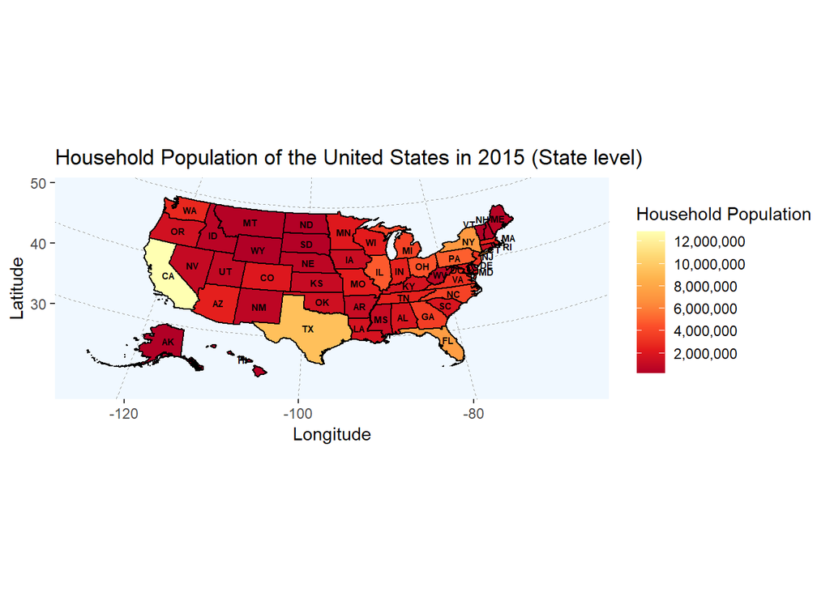

```r
# Plotting a map of household populations across states
states_data <- left_join(statedata, urbnmapr::states, by = "state_fips")
states_label_data <- get_urbn_labels(map = "states")

ggplot() +
  geom_polygon(data = states_data, mapping = aes(x = long, y = lat, group = group, fill = hhpop), color = "black") +
  geom_text(data = states_label_data, aes(label = state_abbv, x = long, y = lat, fontface = "bold"), size = 2) +
  scale_fill_distiller(name="Household Population",
                       palette = "YlOrRd",
                       breaks = breaks_pretty(n = 5),
                       labels = comma) +
  coord_map(projection = "albers", lat0 = 39, lat1 = 45) + # Used to alter map projection for a nicer view
  xlab("Longitude") +
  ylab("Latitude") +
  ggtitle("Household Population of the United States in 2015 (State level)") +
  theme(panel.grid.major = element_line(color = "gray60", linetype = "dashed", size = 0.25),
        panel.background = element_rect(fill = "aliceblue")) +
  theme(aspect.ratio = 0.4)
```

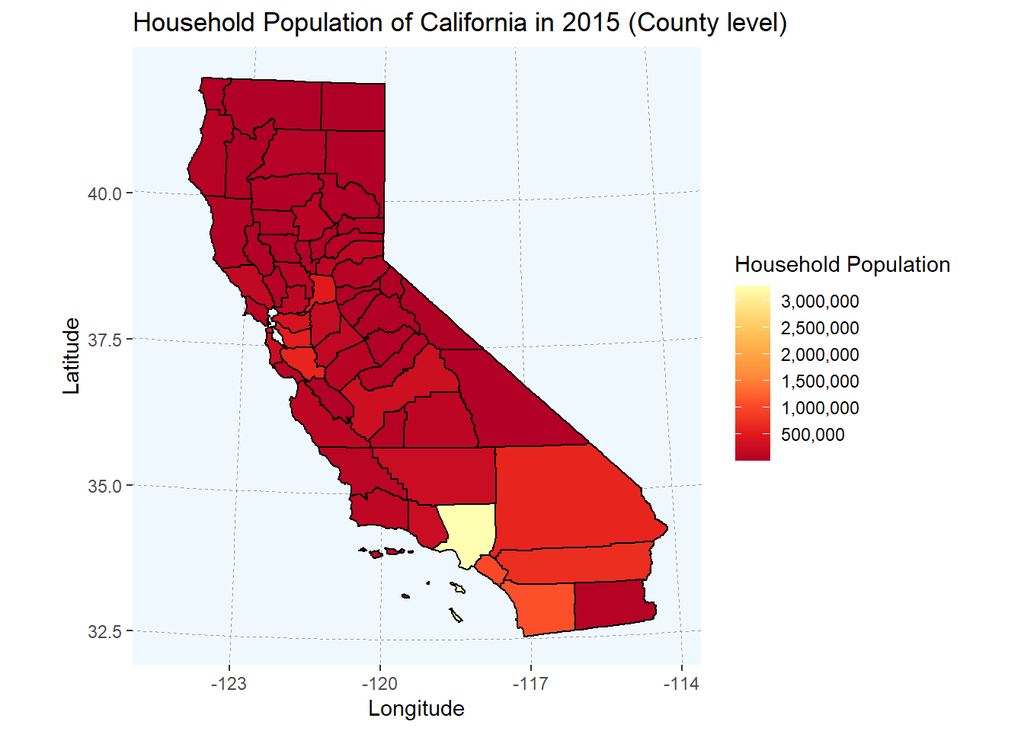

```r
# Plotting a map of household populations across counties in California
counties_data <- left_join(countydata, urbnmapr::counties, by = "county_fips")
counties_data <- counties_data[counties_data$state_name == "California",]

ggplot() +
  geom_polygon(data = counties_data, aes(x = long, y = lat, group = group, fill = hhpop), color = "black") +
  scale_fill_distiller(name="Household Population",
                       palette = "YlOrRd",
                       breaks = breaks_pretty(n = 5),
                       labels = comma) +
  coord_map(projection = "albers", lat0 = 39, lat1 = 45) + # Used to alter map projection for a nicer view
  xlab("Longitude") +
  ylab("Latitude") +
  ggtitle("Household Population of California in 2015 (County level)") +
  theme(panel.grid.major = element_line(color = "gray60", linetype = "dashed", size = 0.25),
        panel.background = element_rect(fill = "aliceblue"))
```

# 4. Using the **tigris** Package

Aside from the **urbnmapr** package, The **tigris** package can be used to plot spatial data in the United States as well. **tigris** is an R package that allows users to directly download and use TIGER/Line shapefiles (https://www.census.gov/geographies/mapping-files/time-series/geo/tiger-line-file.html) from the US Census Bureau.

This package has several advantages over the **urbanmapr** package:  
1. It allows flexibility in plotting maps, such as being able to use “sf” and “sp” classes, being able to rescale maps (Positions of Hawaii, Alaska etc.) to your liking, and being able to plot a greater variety of maps aside from States and Counties (such as Core Based Statistical Areas)  
2. It contains many functions, datasets and shapefiles that will aid you in spatial analysis within the United States. A full list of functions and their descriptions can be found [here.](https://www.rdocumentation.org/packages/tigris/versions/1.4.1)  
3. It is constantly being updated at a more frequent rate, so all information inside are up-to-date.

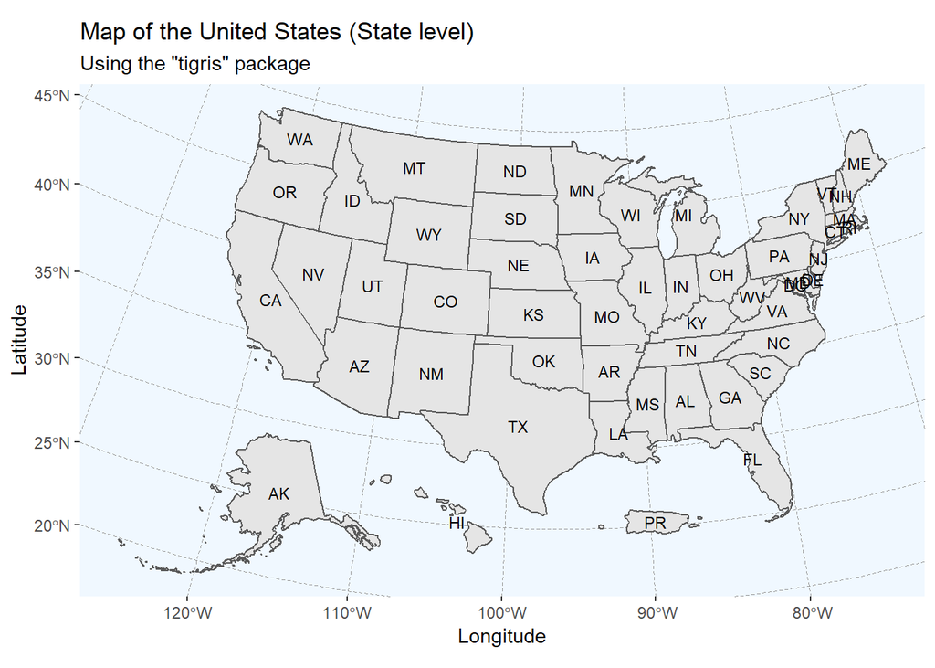

```r
library(sf) # To obtain coordinates of centroids to label states

# To plot a map of the United States at State level - similar to the one done with urbnmapr package
us_states <- states(cb = TRUE, resolution = "20m", progress_bar = FALSE) %>%
  shift_geometry(position = "below") #Additional step to ensure that Hawaii and Alaska are within the visualisations

# To add in coordinates of centroids of all states into the US spatial dataset
us_states <- cbind(us_states,st_coordinates(st_centroid(us_states$geometry)))

ggplot(data = us_states) +
  geom_sf() +
  geom_text(aes(label = STUSPS, x = X, y = Y), size = 3) +
  xlab("Longitude") +
  ylab("Latitude") +
  ggtitle("Map of the United States (State level)", subtitle = "Using the \"tigris\" package") +
  theme(panel.grid.major = element_line(color = "gray60", linetype = "dashed", size = 0.25),
        panel.background = element_rect(fill = "aliceblue"))
```

Here, we can see that Puerto Rico is included in the dataset provided by **tigris**, but not in **urbanmapr**.

Using the **counties()** function, we can plot a county level map of any state we desire. In this case, we are looking at the locations of all fatal motor accidents in New York that have been reported by the United States Department of Transporation in 2019.

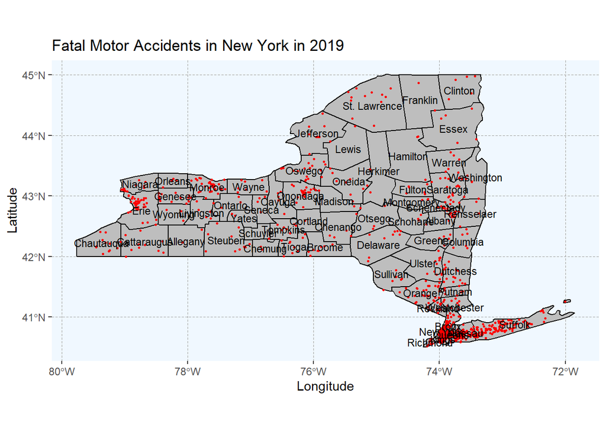

```r
ny_data <- counties(state = "NY", cb = TRUE, resolution = "20m", progress_bar = FALSE)
accidents <- read.csv("accident.csv")
# Longitude filter added to remove outliers
accidents <- accidents[accidents$STATENAME == "New York" & accidents$LONGITUD < 0,]
# Adding Centroid coordinates for labelling purposes
ny_data <- cbind(ny_data, st_coordinates(st_centroid(ny_data$geometry)))

ggplot() +
  geom_sf(data = ny_data, fill = "grey", color = "black") +
  geom_point(data = accidents, aes(x = LONGITUD, y = LATITUDE), color = "red", size = 0.5) +
  geom_text(data = ny_data, aes(label = NAME, x = X, y = Y), size = 3) +
  theme(aspect.ratio = 0.55) +
  xlab("Longitude") +
  ylab("Latitude") +
  ggtitle("Fatal Motor Accidents in New York in 2019") +
  theme(panel.grid.major = element_line(color = "gray60", linetype = "dashed", size = 0.25),
        panel.background = element_rect(fill = "aliceblue"))
```

Using the **counties()** function, you can also plot counties in multiple states easily, by entering your desired states in the “state” argument. In this case we are looking at the locations of all fatal motor accidents in the East Coast of the United States.

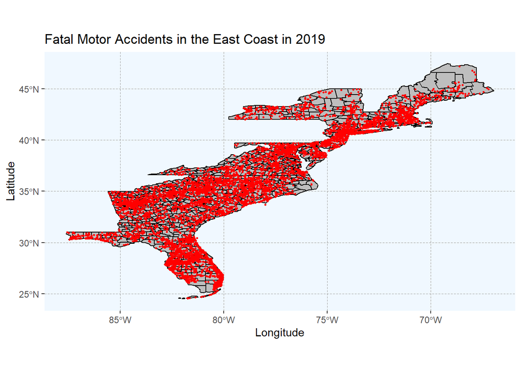

```r
eastcoast <- c("Maine", "New Hampshire", "Massachusetts", "Rhode Island", "Connecticut", "New York", "New Jersey", "Delaware", "Maryland", "Virginia", "North Carolina", "South Carolina", "Georgia", "Florida")
eastcoast_data <- counties(state = eastcoast, cb = TRUE, resolution = "20m", progress_bar = FALSE)
accidents <- read.csv("accident.csv")
# Longitude filter added to remove outliers
accidents <- accidents[(accidents$STATENAME %in% eastcoast) & accidents$LONGITUD < 0,]

# Plotting the locations of all fatal motor accidents in the east coast area of the United States
ggplot() +
  geom_sf(data = eastcoast_data, fill = "grey", color = "black") +
  geom_point(data = accidents, aes(x = LONGITUD, y = LATITUDE), color = "red", size = 0.5) +
  theme(aspect.ratio = 0.55) +
  xlab("Longitude") +
  ylab("Latitude") +
  ggtitle("Fatal Motor Accidents in the East Coast in 2019") +
  theme(panel.grid.major = element_line(color = "gray60", linetype = "dashed", size = 0.25),
        panel.background = element_rect(fill = "aliceblue"))
```

Another benefit of this package is its ability to plot maps of the United States based on its **Core Based Statistical Area (CBSA)**. The US Census Bureau defines these areas as follows: “A metro area contains a core urban area of 50,000 or more population, and a micro area contains an urban core of at least 10,000 (but less than 50,000) population. Each metro or micro area consists of one or more counties and includes the counties containing the core urban area, as well as any adjacent counties that have a high degree of social and economic integration (as measured by commuting to work) with the urban core.”

When data is divided into CBSAs instead of states or counties in the United States, this package will benefit users greatly.

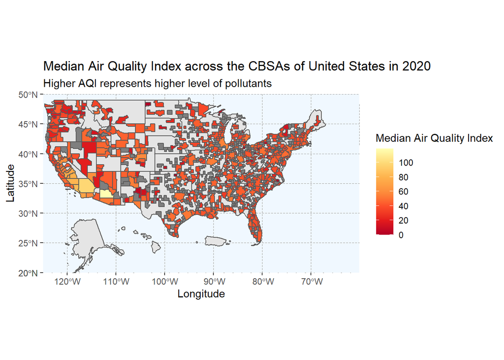

```r
# Air quality data obtained from the United States EPA website
aqi <- read.csv("annual_aqi_by_cbsa_2020.csv")

# Obtaining the United States' CBSA spatial data
cbsa <- core_based_statistical_areas(cb = TRUE, resolution = '20m', progress_bar = FALSE)
cbsa$GEOID <- as.numeric(cbsa$GEOID)

cbsa <- left_join(cbsa, aqi, by = (c("GEOID" = "CBSA.Code")))
# plotting the United States Map at Core Based Statistical Area level
ggplot(data = cbsa) +
  geom_sf(data = us_states) + # To maintain outer borders of the United States
  geom_sf(aes(fill = Median.AQI)) +
  # To show majority of areas, otherwise the plot would be extremely zoomed out
  coord_sf(xlim = c(-125, -60), ylim = c(20,50), expand = FALSE) +
  xlab("Longitude") +
  ylab("Latitude") +
  scale_fill_distiller(name="Median Air Quality Index",
                       palette = "YlOrRd",
                       breaks = breaks_pretty(n = 5)) +
  ggtitle("Median Air Quality Index across the CBSAs of United States in 2020",
          subtitle = "Higher AQI represents higher level of pollutants") +
  theme(panel.grid.major = element_line(color = "gray60", linetype = "dashed", size = 0.25),
        panel.background = element_rect(fill = "aliceblue"))
```

# 5. Plotting maps using the **tmap** Package

Aside from **ggplot2**, **tmap** is another package you can use to plot spatial data. In fact, this package is specifically tailored for plotting maps. We’ll use the examples of bombings around the world, and population of countries in Asia to plot our maps on this package.

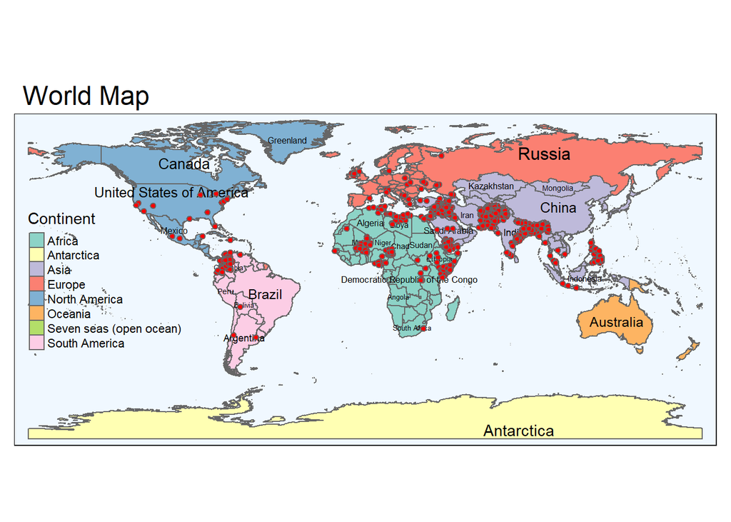

```r
library(sf)
library(tmap)

world <- ne_countries(scale = "large", returnclass = "sf")

# Same dataset as shown previously
terrorism <- read.csv("globalterrorismdb_0919dist.csv")
terrorism2 <- terrorism[terrorism$attacktype1_txt == "Bombing/Explosion" & terrorism$iyear == 2018,]

# To convert this dataset to "sf" in order to be compatible with tmaps
terrorism_clean <- drop_na(terrorism2, c("longitude","latitude")) # sf data do not allow missing coordinates
projcrs <- "+proj=longlat +datum=WGS84 +no_defs +ellps=WGS84 +towgs84=0,0,0" # To specify projection (optional)
terrorism_clean <- st_as_sf(terrorism_clean, coords = c("longitude","latitude"), crs = projcrs)


tm_shape(world) +
  tm_polygons(col = "continent", title = "Continent") + # When variables are categorical, best not to specify palette
  tm_text("admin", size = "AREA") + # Size = "AREA" varies the size of each text based on its polygon size
  tm_layout(main.title = "World Map", bg.color = "aliceblue", legend.position = c("left","center")) +
  tm_shape(terrorism_clean) + tm_symbols(size = 0.15, col = "red")
```

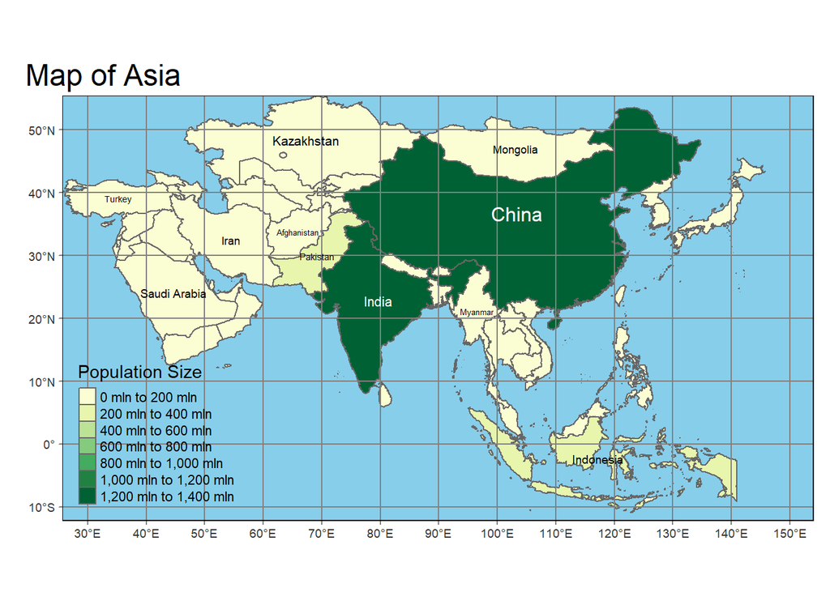

```r
asia <- ne_countries(scale = "large", continent = "asia", returnclass = "sf")
asia$pop_est <- as.numeric(asia$pop_est)

tm_shape(asia) +
  tm_polygons(col = "pop_est", title = "Population Size", palette = "YlGn") +
  tm_graticules() +
  tm_text("admin", size = "AREA") +
  tm_layout(main.title = "Map of Asia", bg.color = "skyblue", legend.position = c("left","bottom"), inner.margins = 0)
```

```r
  # tm_layout(main.title = "Map of Asia", bg.color = "skyblue", legend.outside = TRUE, inner.margins = 0)
  # Use this tm_layout line instead of the one above to move legend outside of the plot
```

Preset map settings are also available using the **tmap_style()** funcion

```r
tmap_style("classic")
```

```
## tmap style set to "classic"
```

```
## other available styles are: "white", "gray", "natural", "cobalt", "col_blind", "albatross", "beaver", "bw", "watercolor"
```

```
## Scale bar set for latitude km and will be different at the top and bottom of the map.
```

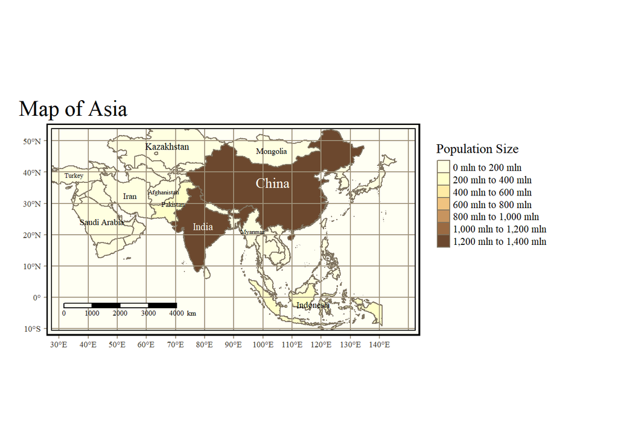

```r
# other available styles are: "white", "gray", "natural", "cobalt", "col_blind", "albatross", "beaver", "bw", "watercolor"

tm_shape(asia) +
  tm_polygons(col = "pop_est", title = "Population Size") +
  tm_graticules() +
  tm_text("admin", size = "AREA") +
  tm_layout(main.title = "Map of Asia", legend.outside = TRUE, inner.margins = 0) +
  tm_scale_bar(position = "left")
```

Maps can also be made with just one function, qtm(), which stands for Quick Thematic Map.

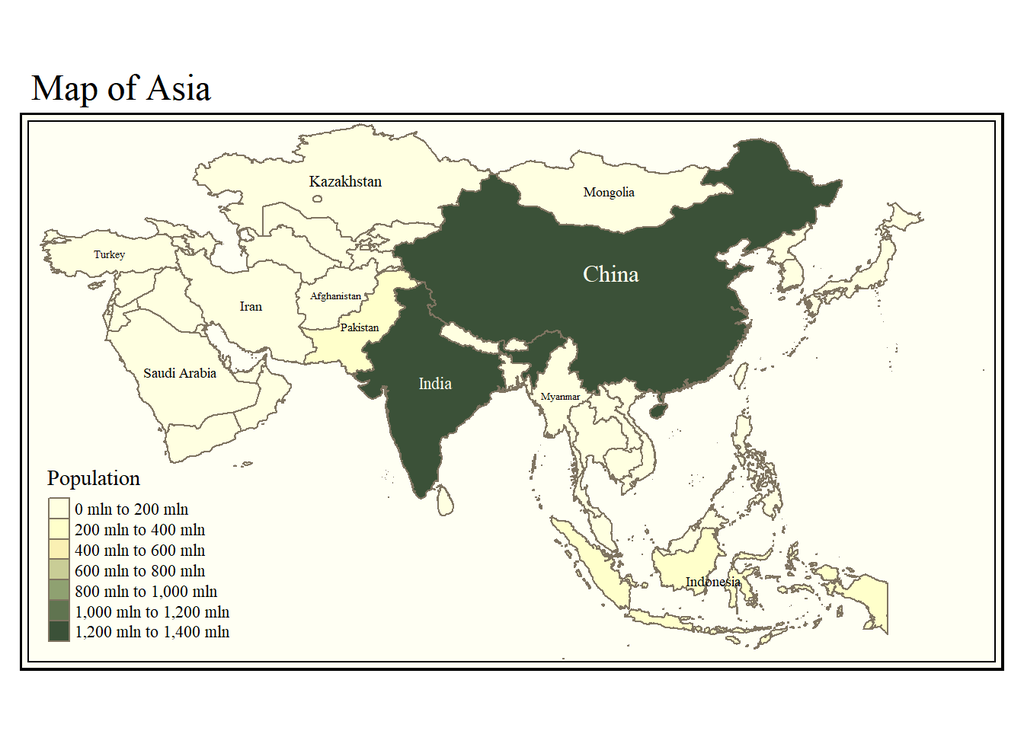

```r
qtm(asia, "pop_est", fill.palette = "YlGn", text = "admin", text.size = "AREA", fill.title = "Population", main.title = "Map of Asia")
```

Using the **tmap** package, we can also create animated maps to replace faceted maps, which might not be ideal as faceted maps squeeze multiple maps into a single screen and might not be easy to read. In the example below, we can use animated maps to show how the distribution of bombings across the world varied from year to year, instead of showing a single year like in the above example. The **gifski** package will also be required when converting the faceted maps into a gif file.

```r
library(gifski)

terrorism3 <- terrorism[terrorism$attacktype1_txt == "Bombing/Explosion",]

# To convert this dataset to "sf" in order to be compatible with tmaps
terrorism_clean2 <- drop_na(terrorism3, c("longitude","latitude")) # sf data do not allow missing coordinates
projcrs <- "+proj=longlat +datum=WGS84 +no_defs +ellps=WGS84 +towgs84=0,0,0" # To specify projection (optional)
terrorism_clean2 <- st_as_sf(terrorism_clean2, coords = c("longitude","latitude"), crs = projcrs)

# Creating the faceted maps
terrorism_anim <- tm_shape(world) +
  tm_polygons(col = "continent", title = "Continent") + # When variables are categorical, best not to specify palette
  tm_text("admin", size = "AREA") + # Size = "AREA" varies the size of each text based on its polygon size
  tm_layout(bg.color = "aliceblue", legend.position = c("left","center")) +
  tm_shape(terrorism_clean2) + tm_symbols(size = 0.15, col = "red") +
  tm_facets(along = "iyear", free.coords = FALSE)

# Converted the faceted maps into a gif
tmap_animation(terrorism_anim, filename = "terrorism_anim.gif", delay = 25) # Delay in terms of 1/100th of a second
```

After running the above code, you’ll be obtain a gif file as you can see below:

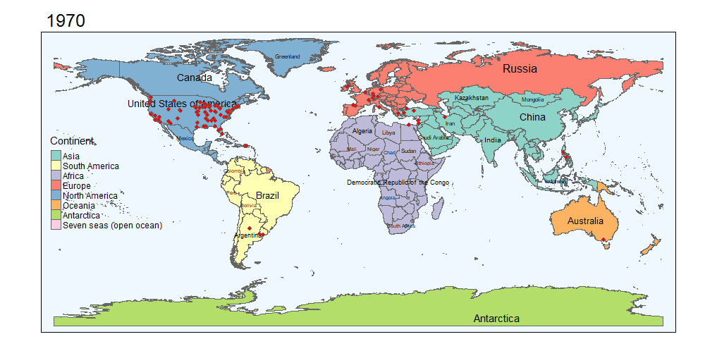

# 6. Loading shapefiles downloaded online for spatial visualisation

You can also download your own shapefiles, and load them into r. As an example, when we plotted a map of Singapore, the boundaries provided by packages covered before only covered up to the various major regions (i.e. Central, NorthWest, etc.). However, we can also download Singapore’s polygon data (.shp files) from public data available. An example can be found [here.](https://data.gov.sg/dataset/master-plan-2014-planning-area-boundary-web?resource_id=2ab23cb2-b1a4-4b1a-a9e1-b9cad0ac159b) Afterwards, we can load the file in to r using the **readOGR()** function as follows:

```r
sg_plan <- readOGR(dsn = "~/RAStuff", layer = "MP14_PLNG_AREA_WEB_PL")
# dsn refers to the path of your folder containing your .shp file, layer refers to the name of the .shp file without the .shp extension.

summary(sg_plan)
```

```
## Object of class SpatialPolygonsDataFrame
## Coordinates:
##         min      max
## x  2667.538 56396.44
## y 15748.721 50256.33
## Is projected: TRUE
## proj4string :
## [+proj=tmerc +lat_0=1.36666666666667 +lon_0=103.833333333333 +k=1
## +x_0=28001.642 +y_0=38744.572 +datum=WGS84 +units=m +no_defs]
## Data attributes:
##     OBJECTID     PLN_AREA_N         PLN_AREA_C           CA_IND
##  Min.   : 1.0   Length:55          Length:55          Length:55
##  1st Qu.:14.5   Class :character   Class :character   Class :character
##  Median :28.0   Mode  :character   Mode  :character   Mode  :character
##  Mean   :28.0
##  3rd Qu.:41.5
##  Max.   :55.0
##    REGION_N           REGION_C           INC_CRC           FMEL_UPD_D
##  Length:55          Length:55          Length:55          Length:55
##  Class :character   Class :character   Class :character   Class :character
##  Mode  :character   Mode  :character   Mode  :character   Mode  :character
##
##
##
##      X_ADDR          Y_ADDR        SHAPE_Leng       SHAPE_Area
##  Min.   : 5688   Min.   :25070   Min.   :  4386   Min.   :  830273
##  1st Qu.:21930   1st Qu.:31596   1st Qu.: 13238   1st Qu.: 6630102
##  Median :28530   Median :34689   Median : 16933   Median :10100544
##  Mean   :27627   Mean   :36004   Mean   : 20852   Mean   :14217178
##  3rd Qu.:32092   3rd Qu.:40148   3rd Qu.: 22022   3rd Qu.:16652231
##  Max.   :50425   Max.   :48595   Max.   :111547   Max.   :69748299
```

Afterwards, we can look to plot the polygon data obtained.

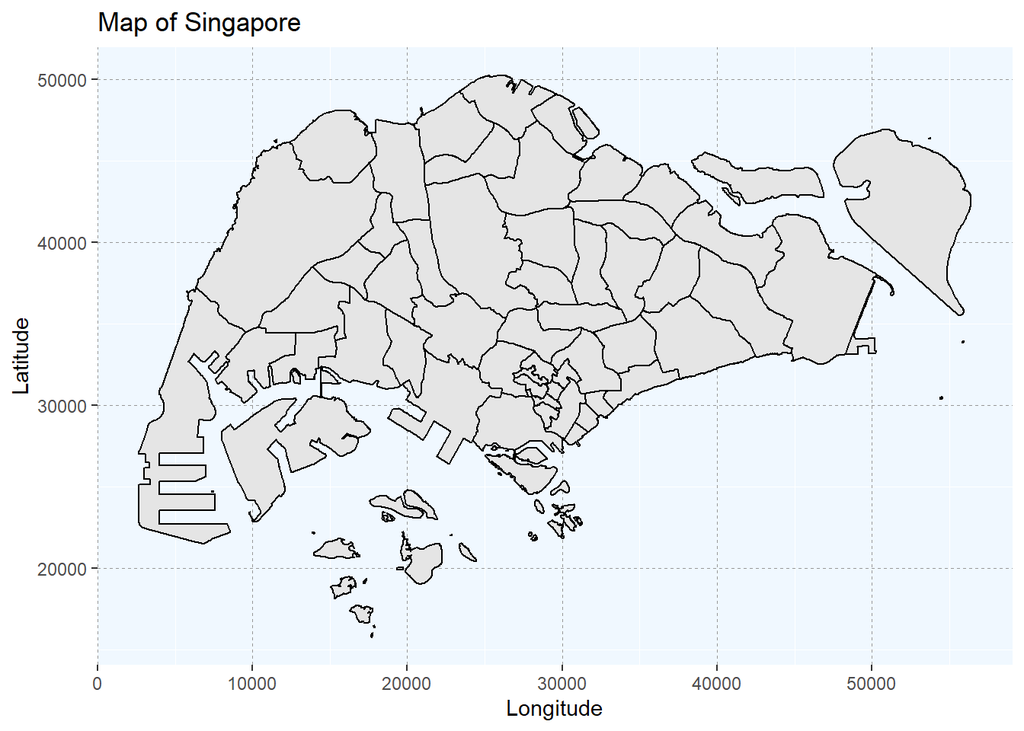

```r
# To plot the polygon data downloaded
ggplot() +
  geom_polygon(data = sg_plan, aes(x = long, y = lat, group = group), color = "black", fill = "gray90") +
  theme(panel.grid.major = element_line(color = "gray60", linetype = "dashed", size = 0.25),
        panel.background = element_rect(fill = "aliceblue")) +
  xlab("Longitude") +
  ylab("Latitude") +
  ggtitle("Map of Singapore")
```

```
## Warning in sp::proj4string(obj): CRS object has comment, which is lost in output
```

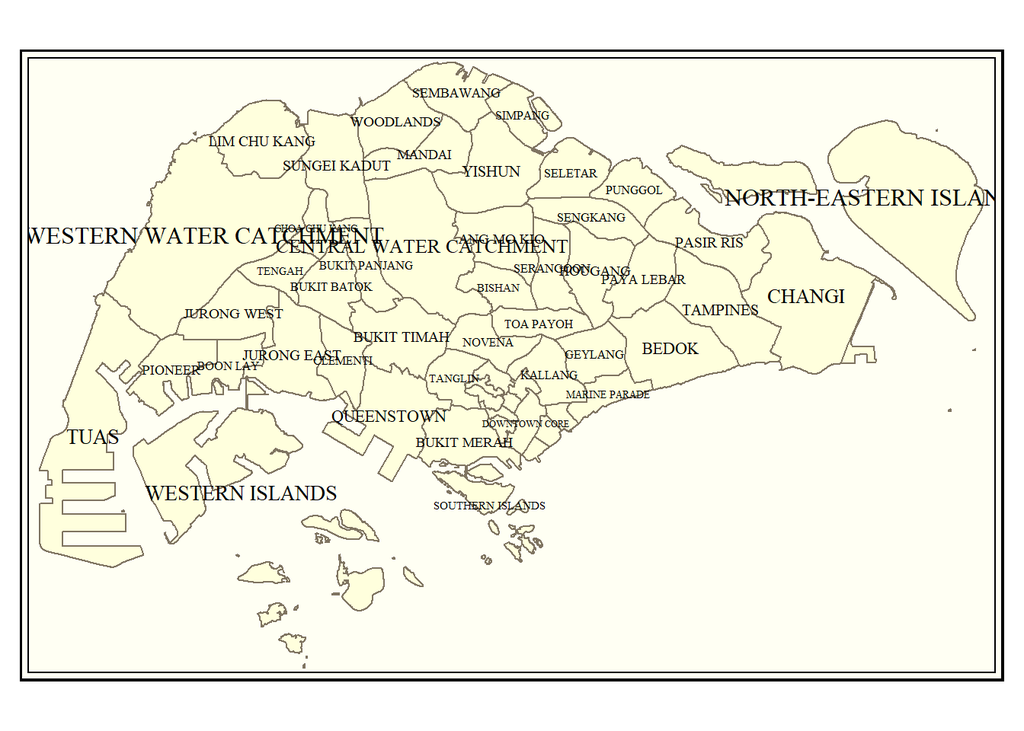

```r
# Alternative method to plot
tm_shape(sg_plan) + tm_polygons() + tm_text("PLN_AREA_N", size = "AREA")
```

Compared to the previous maps of Singapore shown, this is more detailed when it comes to the number of border lines surrounding the various regions of Singapore. Now we are able to view more specific areas such as “Yishun”, “Tuas” and so on.

It is important to note that a shapefile should consist of at least four files: .shp (the geometry), .dbf (the attributes), .shx (the index that links the two, and .prj (the coordinate reference system). If the .prj file is missing, a warning is given. If any other file is missing an error occurs (although one could in principle recover the .shx from the .shp file).

When downloading the polygon data file provided in the link above, it is important to copy all the files in the folder (instead of just the .shp file), or the **readOGR()** function will not work.